# Lieber 2024 TRACE ISA

Bob Policastro

## Libraries

Load the required libraries for the analysis.

```r
library("tidyverse")
library("patchwork")
library("randomcoloR")
library("ggseqlogo")
library("Biostrings")
library("karyoploteR")
library("GenomicFeatures")
library("GenomicRanges")
library("GenomeInfoDb")
library("Rsamtools")
library("readr")
library("ChIPseeker")
```

## Prepare Data

Load the annotated insertion sites from the Ensoma TRACE ISA workflow.

```r
# Get a list of files to load.
isa_files <-
  file.path("data", "insertion_sites") |>
  list.files(pattern="filtered\\.tsv$", full.names=TRUE)

# Load the files.
isa <- isa_files |>
  tibble(file_path=_) |>
  mutate(
    file_name=basename(file_path),
    data=map(file_path, read_tsv, show_col_types=FALSE)
  ) |>
  unnest(data) |>
  # Remove the Illumina stuff from the sample names.
  mutate(file_id=str_remove(sample_id, "_S\\d+_L00\\d\\.\\S+$")) |>
  relocate(file_id, .after=sample_id)
```

Load the sample sheet that has additional information for each sample. Then join the information with the ISA results.

```r
# Load the sample sheet.
sample_sheet <- read_csv(
  file.path("data", "sample_sheet.csv"), show_col_types=FALSE
)

# Join into the isa data.
isa <- left_join(isa, sample_sheet, by="file_id")
```

Only keep insertion sites that appear in at least 2 of 3 technical replicates. Return the sum of values for the group of technical replicates.

```r
isa <- isa |>
  # Keep only insertion sites that appear in at least 2 technical replicates.
  group_by(sample_name, seqnames, start, end, strand) |>
  filter(n() > 1) |>
  ungroup() |>
  # Sum the score for each insertion site across replicates.
  group_by(
    sample_name, seqnames, start, end, strand, annotation, tss_distance
  ) |>
  summarize(score=sum(score), .groups="drop")
```

Annotate the insertion sites.

```r
# Download the mouse GTF file if it doesn't exist.
if (!file.exists(file.path("data", "Mus_musculus.GRCm39.111.chr.gtf.gz"))) {
  download.file(
    "https://ftp.ensembl.org/pub/release-111/gtf/mus_musculus/Mus_musculus.GRCm39.111.chr.gtf.gz",
    file.path("data", "Mus_musculus.GRCm39.111.chr.gtf.gz"),
    method="wget"
  )
}

# Load the annotation as a TxDb.
txdb <-
  file.path("data", "Mus_musculus.GRCm39.111.chr.gtf.gz") |>
  makeTxDbFromGFF()
```

```
#> Import genomic features from the file as a GRanges object ... OK
#> Prepare the 'metadata' data frame ... OK
#> Make the TxDb object ...
#> Warning in .get_cds_IDX(mcols0$type, mcols0$phase): The "phase" metadata column contains non-NA values for features of type
#>   stop_codon. This information was ignored.
#> OK
```

```r
# Reannotate the insertion sites.
isa_anno <- isa |>
  dplyr::select(!c(annotation, tss_distance)) |>
  makeGRangesFromDataFrame(keep.extra.columns=TRUE) |>
  annotatePeak(
    peak=_,
    tssRegion=c(-2000, 200),
    TxDb=txdb,
    level="transcript",
    sameStrand=FALSE
  ) |>
  as_tibble()
```

```
#> >> preparing features information...      2024-06-19 01:31:11
#> >> identifying nearest features...        2024-06-19 01:31:11
#> >> calculating distance from peak to TSS...   2024-06-19 01:31:12
#> >> assigning genomic annotation...        2024-06-19 01:31:12
#> >> assigning chromosome lengths           2024-06-19 01:31:29
#> >> done...                    2024-06-19 01:31:29
```

```r
isa <- dplyr::select(
  isa_anno,
  sample_name, seqnames, start, end, strand, annotation,
  tss_distance=distanceToTSS, score
)
```

Export the filtered insertion sites for inclusion in the final paper.

```r
isa_anno |>
  left_join(
    sample_sheet |>
      dplyr::select(
        sample_name, species, sample_source, gene_marking_percent
      ) |>
      distinct(),
    by="sample_name"
  ) |>
  dplyr::select(
    sample_name, seqnames, start, end, width, strand, score,
    annotation_detailed=annotation, tss_distance=distanceToTSS,
    gene_seqnames=geneChr, gene_start=geneStart, gene_end=geneEnd,
    gene_width=geneLength, gene_strand=geneStrand, gene_id=geneId,
    transcript_id=transcriptId, species, sample_source, gene_marking_percent
  ) |>
  mutate(
    annotation_simple=str_remove(annotation_detailed, "\\s\\(.+$"),
    sample_name=factor(
      sample_name, levels=str_sort(unique(sample_name), numeric=TRUE)
    ),
    seqnames=factor(seqnames, levels=str_sort(unique(seqnames), numeric=TRUE))
  ) |>
  dplyr::relocate(annotation_simple, .after=annotation_detailed) |>
  arrange(sample_name, desc(score), seqnames, start) |>
  write_tsv(file.path("results", "TRACE_insertion_sites_annotated.tsv"))
```

Set the factor levels of the sample names so they appear in a consistent order in the plots.

```r
sample_name_order <- c(
  "Mouse BM (65.10%)", "Mouse BM (62.20%)", "Mouse BM (38.90%)",
  "Mouse BM (37.00%)", "Mouse BM (25.00%)", "Mouse BM (0.00%)"
)

isa <- mutate(
  isa, sample_name=factor(sample_name, levels=sample_name_order)
)
```

## Number and Frequency of Insertion Sites

Generate a bar graph of the number of insertion sites per sample. This is defined as the number of unique genomic locations for each sample where an insertion event was detected.

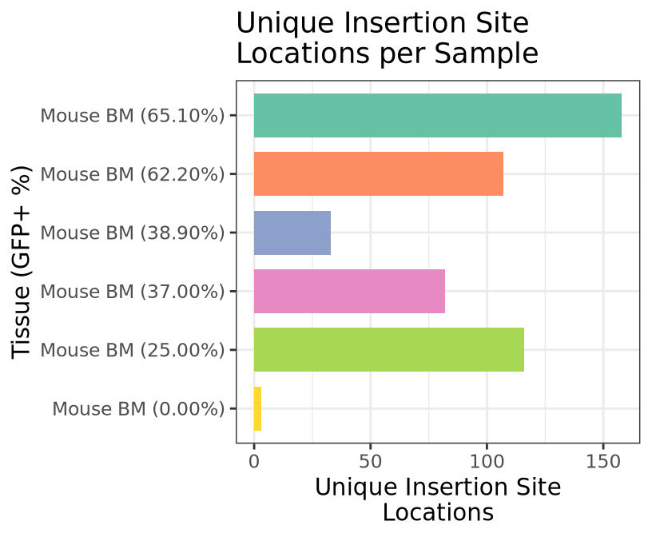

```r
p1 <- isa |>
  count(sample_name) |>
  ggplot(aes(x=n, y=fct_rev(sample_name))) +
    geom_col(width=0.75, aes(fill=sample_name), show.legend=FALSE) +
    theme_bw() +
    labs(
      x="Unique Insertion Site\nLocations",
      y="Tissue (GFP+ %)",
      title="Unique Insertion Site\nLocations per Sample"
    ) +
    scale_fill_brewer(palette="Set2")

print(p1)
```

```r
if (!dir.exists("results")) dir.create("results")

ggsave(
  file.path("results", "insertion_sites_per_sample.pdf"), plot=p1,
  device=cairo_pdf, height=3.5, width=4.25
)
```

Multiple unique sequenced fragments can end up mapping to the same genomic location in the same sample. This is likely due to the clonal expansion of a cell with a particular genomic insertion site. This bargraph represents all fragments of DNA with insertion sites sequenced for each sample regardless of genomic location.

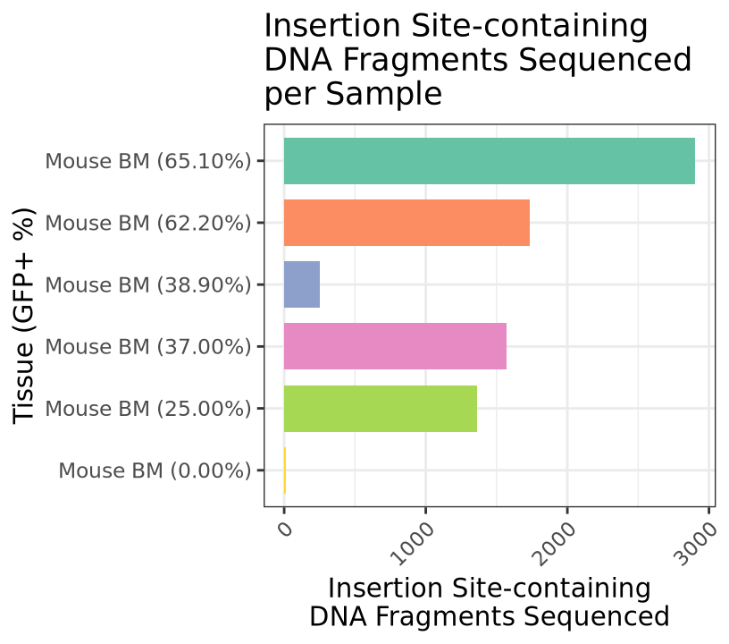

```r
p2 <- isa |>
  # Sum the total number of unique fragments for each sample.
  group_by(sample_name) |>
  summarize(score=sum(score), .groups="drop") |>
  # Plot the total number of unique fragments for each sample.
  ggplot(aes(x=score, y=fct_rev(sample_name))) +
    geom_col(width=0.75, aes(fill=sample_name), show.legend=FALSE) +
    theme_bw() +
    theme(axis.text.x=element_text(angle=45, hjust=1)) +
    labs(
      x="Insertion Site-containing\nDNA Fragments Sequenced",
      y="Tissue (GFP+ %)",
      title="Insertion Site-containing\nDNA Fragments Sequenced\nper Sample"
    ) +
    scale_fill_brewer(palette="Set2")

print(p2)
```

```r
ggsave(
  file.path("results", "insertion_sites_sequenced_per_sample.pdf"), plot=p2,
  device=cairo_pdf, height=3.5, width=4.25
)
```

Combine the previous two plots into one figure for publication.

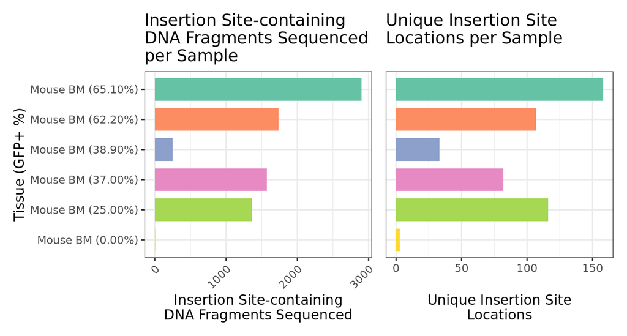

```r
p <-
  (p2 + p1) +
  plot_layout(axes="collect_y")

print(p)
```

```r
ggsave(
  file.path("results", "insertion_sites_for_figure.pdf"), plot=p,
  device=cairo_pdf, height=3.75, width=7
)
```

As described above, a sample can have multiple DNA fragments with insertion sites mapping to the same genomic location. This stacked barplot represents for each genomic location with an insertion site in the sample, the fraction of insertion-site containing DNA fragments sequenced associated with that site.

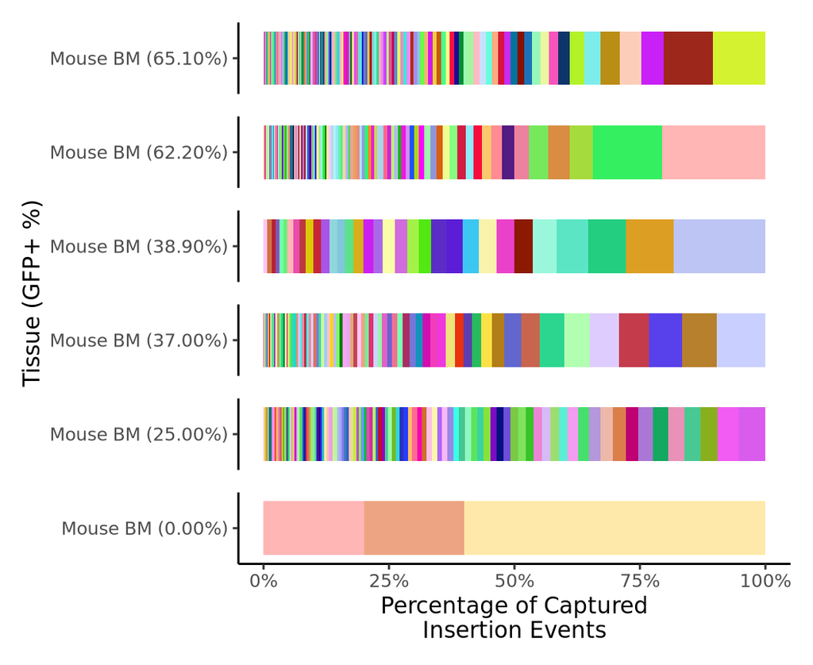

```r
# Function to generate random color palette.
random_pal <- function(vals) {
  n_vals <- length(unique(vals))
  color_map <- unique(randomcoloR::randomColor(n_vals + 1000))[1:n_vals]
  names(color_map) <- unique(vals)
  colors <- vapply(vals, \(x) color_map[x], character(1))
  return(colors)
}

# Prepare data for plotting.
df <- isa |>
  # Summarize the fraction of reads per insertion site.
  dplyr::group_by(sample_name) |>
  dplyr::mutate(frac=score / sum(score)) |>
  dplyr::ungroup() |>
  # Add a column with the custom colors.
  dplyr::mutate(
      posid=paste(seqnames, start, end, strand, sep=":"),
      color=random_pal(posid),
      sample_id=factor(
          sample_name,
          levels=rev(stringr::str_sort(unique(sample_name)))
      )
  ) |>
  split(~sample_name) |>
  lapply(\(x) {
      x <- x |>
          dplyr::mutate(
              color=forcats::fct_drop(color),
              color=forcats::fct_reorder(color, frac, .desc=TRUE)
          )
      return(x)
  })

# Create the plots.
p <- df |>
  imap(\(x, y) {
    ggplot(x, aes(x=frac, y=sample_name)) +
      geom_col(aes(fill=color)) +
      scale_fill_identity() +
      scale_x_continuous(labels=scales::percent) +
      theme_classic() +
      labs(
        x="Percentage of Captured\nInsertion Events",
        y="Tissue (GFP+ %)"
      )
  }) |>
  wrap_plots(ncol=1) +
    plot_layout(axes="collect", axis_titles="collect")

print(p)
```

```r
ggsave(
  file.path("results", "insertion_site_percentage_per_sample.pdf"),
  plot=p, device=cairo_pdf, height=4.5, width=5.5
)
```

## Genomic Distribution

We first need to calculate the overall feature distribution of the mouse genome. The first step is to download the assembly and get the total genome length.

```r
assembly_url <-
  "https://ftp.ensembl.org/pub/release-111/fasta/mus_musculus/dna/Mus_musculus.GRCm39.dna.primary_assembly.fa.gz"

index_file <- file.path(
  "data", "Mus_musculus.GRCm39.dna.primary_assembly.fa.fai"
)

if (!file.exists(index_file)) {
  # Download the genome assembly.
    download.file(
      assembly_url,
      file.path("data", "Mus_musculus.GRCm39.dna.primary_assembly.fa.gz"),
      method="wget"
    )

  # Unzip the file.
  system2(
    "gunzip",
    file.path("data", "Mus_musculus.GRCm39.dna.primary_assembly.fa.gz")
  )

  # Index the genome assembly.
  indexFa(file.path("data", "Mus_musculus.GRCm39.dna.primary_assembly.fa"))
}

# Load the index.
genome_length <- index_file |>
  read_tsv(
    col_names=c(
      "seqnames", "width", "byte_index", "bases_per_line", "bytes_per_line"
    ),
    col_types=c("c", rep("i", 4))
  ) |>
  pull(width) |>
  sum()
```

Now that the total genome size has been obtained we can get the fraction of the genome contained within each annotation. The priority of annotations is as follows: Promoter, 3’ UTR, exonic, intronic, downstream, and distal intergenic.

```r
# Download the mouse GTF file if it doesn't exist.
if (!file.exists(file.path("data", "Mus_musculus.GRCm39.111.chr.gtf.gz"))) {
  download.file(
    "https://ftp.ensembl.org/pub/release-111/gtf/mus_musculus/Mus_musculus.GRCm39.111.chr.gtf.gz",
    file.path("data", "Mus_musculus.GRCm39.111.chr.gtf.gz"),
    method="wget"
  )
}

# Load the GTF file as a TxDb object.
gtf <- makeTxDbFromGFF(file.path("data", "Mus_musculus.GRCm39.111.chr.gtf.gz"))
```

```
#> Import genomic features from the file as a GRanges object ... OK
#> Prepare the 'metadata' data frame ... OK
#> Make the TxDb object ...
#> Warning in .get_cds_IDX(mcols0$type, mcols0$phase): The "phase" metadata column contains non-NA values for features of type
#>   stop_codon. This information was ignored.
#> OK
```

```r
# Portion of genome that is promoter.
promoter_regions <- gtf |>
  transcripts() |>
  promoters(upstream=2000, downstream=200) |>
  GenomicRanges::reduce()

promoter_sum <- promoter_regions |>
  width() |>
  sum()

# Portions of genome that are 3' UTR but not promoter.
three_prime_utr_regions <- gtf |>
  threeUTRsByTranscript() |>
  unlist() |>
  GenomicRanges::reduce() |>
  GenomicRanges::setdiff(promoter_regions)

three_prime_utr_sums <- three_prime_utr_regions |>
  width() |>
  sum()

# Portion of genome that is exonic but not promoter or 3' UTR.
exonic_regions <- gtf |>
  exons() |>
  GenomicRanges::reduce() |>
  GenomicRanges::setdiff(c(promoter_regions, three_prime_utr_regions))

exonic_sum <- exonic_regions |>
  width() |>
  sum()

# Portion of the genome that is introniuc but not promoter, 3' UTR, or exonic.
intronic_regions <- gtf |>
  intronsByTranscript() |>
  unlist() |>
  GenomicRanges::reduce() |>
  GenomicRanges::setdiff(c(
    promoter_regions, three_prime_utr_regions, exonic_regions
  ))

intronic_sum <- intronic_regions |>
  width() |>
  sum()

# Portion of the genome that is downstream from the gene but not in any
# promoters, 3' UTRs, exonic, or intronic regions.
get_downstream_regions <- function(genes, distance) {
  downstream <- genes

  start(downstream)[as.character(strand(genes)) == "+"] <-
    end(genes)[as.character(strand(genes)) == "+"] + 1
  end(downstream)[as.character(strand(genes)) == "+"] <-
    end(genes)[as.character(strand(genes)) == "+"] + distance

  end(downstream)[as.character(strand(genes)) == "-"] <-
    start(genes)[as.character(strand(genes)) == "-"] - 1
  start(downstream)[as.character(strand(genes)) == "-"] <-
    start(genes)[as.character(strand(genes)) == "-"] - distance

  return(downstream)
}

downstream_regions <- gtf |>
  genes() |>
  get_downstream_regions(3000) |>
  GenomicRanges::reduce() |>
  GenomicRanges::setdiff(c(
    promoter_regions, three_prime_utr_regions, exonic_regions, intronic_regions
  ))

downstream_sum <- downstream_regions |>
  width() |>
  sum()

# Caluclate the distal intergenic length.
distal_intergenic_length <-
  genome_length - (
    promoter_sum +
    three_prime_utr_sums +
    exonic_sum +
    intronic_sum +
    downstream_sum
  )

# Get the percentage of the genome that is each feature.
feature_perc <-
  tibble(
    sample_name="Mouse Genome",
    annotation=c(
      "Promoter", "3' UTR", "Exon", "Intron", "Downstream", "Distal Intergenic"
    ),
    n=c(
      promoter_sum,
      three_prime_utr_sums,
      exonic_sum,
      intronic_sum,
      downstream_sum,
      distal_intergenic_length
    )
  ) |>
  mutate(frac=n/sum(n))
```

Finally we will plot the distribution of insertion sites relative to genomic features for each sample. The overall distribution of genomic features calculated earlier will will be included as reference.

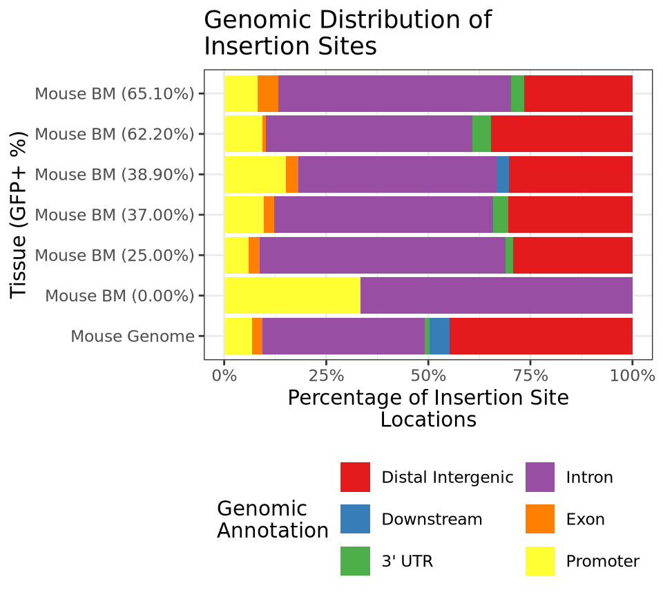

```r
annotation_factor_order <- c(
  "Promoter", "Exon", "Intron", "3' UTR", "Downstream", "Distal Intergenic"
)

name_order <- c(
  "Mouse BM (65.10%)", "Mouse BM (62.20%)", "Mouse BM (38.90%)",
  "Mouse BM (37.00%)", "Mouse BM (25.00%)", "Mouse BM (0.00%)",
  "Mouse Genome"
)

p <- isa |>
  # Remove superfluous parts of the annotation values.
  mutate(annotation=str_remove(annotation, "\\s\\(.+$")) |>
  # Get the fraction of insertion sites associated with each genomic annotation.
  count(sample_name, annotation) |>
  group_by(sample_name) |>
  mutate(frac=n/sum(n)) |>
  ungroup() |>
  complete(sample_name, annotation, fill=list(n=0)) |>
  # Add the general mouse genome stats.
  bind_rows(feature_perc) |>
  mutate(
    annotation=factor(annotation, levels=annotation_factor_order),
    sample_name=factor(sample_name, levels=name_order)
  ) |>
  # Create the stacked barplot.
  ggplot(aes(x=frac, y=fct_rev(sample_name))) +
    geom_col(aes(fill=fct_rev(annotation))) +
    scale_fill_brewer(palette="Set1") +
    scale_x_continuous(labels=scales::percent) +
    theme_bw() +
    theme(
      legend.position="bottom"
    ) +
    guides(fill=guide_legend(ncol=2)) +
    labs(
      title="Genomic Distribution of\nInsertion Sites",
      x="Percentage of Insertion Site\nLocations",
      y="Tissue (GFP+ %)",
      fill="Genomic\nAnnotation"
    )

print(p)
```

```r
ggsave(
  file.path("results", "insertion_site_genomic_locations.pdf"),
  plot=p, device=cairo_pdf, height=4.5, width=5
)
```

For all insertion sites appearing in at least two technical replicates, create a sequence logo centered around the insertion site including ±20 bps.

Sleeping beauty is known to have a palindromic motif at the insertion site with A(-3), T(0), A(+1), and T(+4).

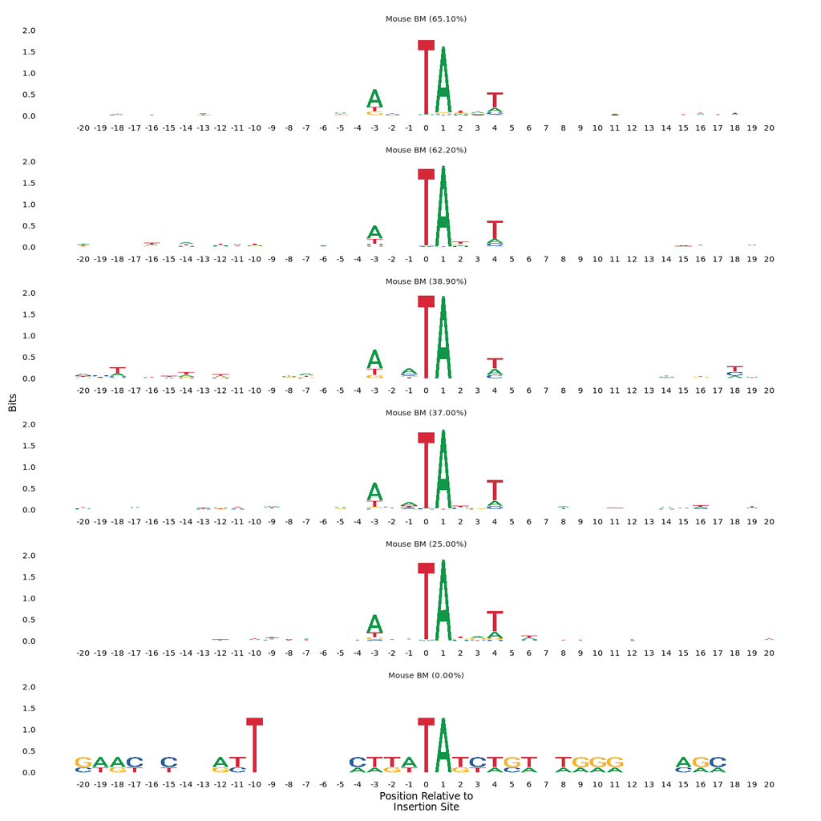

```r
# Load the FASTA data into a table.
fasta_files <-
  file.path("data", "insertion_site_sequences") |>
  list.files(pattern="\\.fasta$", full.names=TRUE) |>
  tibble(file_path=_) |>
  mutate(
    file_id=str_remove(basename(file_path), "_S\\d+_L00\\d\\.\\S+"),
    data=map(file_path, readDNAStringSet),
    posid=map(data, names),
    seq=map(data, \(x) {unname(as.character(x))})
  ) |>
  left_join(
    dplyr::select(sample_sheet, file_id, sample_name),
    by="file_id"
  ) |>
  dplyr::select(!c(data, file_path, file_id)) |>
  unnest(c(posid, seq)) |>
  distinct() |>
  separate_wider_regex(
    posid, c(
      seqnames="^\\S+", ":", start="\\d+", "-", end="\\d+", "\\(",
      strand="[\\+\\-]", "\\)"
    ),
    cols_remove=FALSE
  ) |>
  mutate(across(c(start, end), as.numeric))

# Remove insertion sites that appeared in less than 2 technical replicates.
fasta_files <- semi_join(
  fasta_files,
  mutate(isa, start=start - 21, end=end + 20),
  by=c("sample_name", "seqnames", "start", "end", "strand")
)

# Turn it into a named list for ggseqlogo.
fasta_files <- fasta_files |>
  split(~sample_name) |>
  map(pull, seq)

# Order the sequences.
fasta_files <- fasta_files[levels(isa$sample_name)]

# Create the sequence logos.
p <- ggseqlogo(fasta_files, ncol=1, seq_type="dna") +
  theme(
    text=element_text(size=7)
  ) +
  scale_x_continuous(breaks=seq_len(41), labels=seq(-20, 20, 1)) +
  labs(
    x="Position Relative to\nInsertion Site"
  )

print(p)
```

```r
ggsave(
  file.path("results", "insertion_site_seqlogo.pdf"),
  plot=p, device=cairo_pdf, height=8, width=8
)
```

For each sample plot the location of the insertion sites relative to their chromosomal location on a karyogram.

```r
# Create GRanges for each sample.
is_granges <- isa |>
  dplyr::select(sample_name, seqnames, start, end, strand, score) |>
  mutate(seqnames=str_c("chr", seqnames)) |>
  split(~ sample_name) |>
  map(makeGRangesFromDataFrame, keep.extra.columns=TRUE)

if (!dir.exists(file.path("results", "karyoplots"))) {
  dir.create(file.path("results", "karyoplots"))
}

# Increase the top plot margin so the title doesn't get cut off.
pp <- getDefaultPlotParams(plot.type=1)
pp$topmargin <- 300

# Create a plot for each sample.
iwalk(is_granges, \(x, y) {
  species <- ifelse(str_starts(y, "Human"), "hg38", "mm39")

  file_name <- y |>
    str_to_lower() |>
    str_replace_all(c(" "="_", "%"="")) |>
    str_glue("{file}_karyoplot.pdf", file=_)

  par(mar=c(1, 1, 10, 1))
  cairo_pdf(
    filename=file.path("results", "karyoplots", file_name),
    height=5, width=6
  )

  p <- plotKaryotype(genome=species, main=y, plot.params=pp)
  kpSegments(p, x, y1=0.5, y0=0, col="royalblue")

  dev.off()
})
```